# Structural VARs and Identification

Natasha Kang

Xiamen University, Chow Institute

May, 2026

## Where We Are

In Unit 7 we built **reduced-form** VARs:

$$x_t = c + A_1 x_{t-1} + \cdots + A_p x_{t-p} + u_t,
\qquad \mathbb{E}(u_t u_t') = \Sigma_u .$$

These describe the joint dynamics of $x_t$ — how variables co-move and how the system propagates over time.

This unit asks a different kind of question:

> *What happens to GDP if the central bank surprises markets with a 25 bp hike today?*

Answering it requires an extra layer of structure — **identification** — that turns reduced-form estimates into causal ones.

## Two Questions a VAR Can Answer …

**Question 1 — Forecasting.** Given everything we know up to today, what is our best guess for next quarter?

$$\hat x_{t+h\mid t}
= \mathbb{E}(x_{t+h} \mid x_t, x_{t-1}, \ldots).$$

The reduced form is sufficient. We never have to ask *why* variables co-move — only that they do.

**Question 2 — Granger causality.** Does the past of $X$ help predict $Y$ beyond what the past of $Y$ alone does? In a VAR, a joint $F$-test on the lag coefficients of $X$ in the equation for $Y$.

The name is misleading: this is about **predictability**, not causation. A barometer’s reading Granger-causes the weather, but turning its dial does not bring rain.

## … And One It Can’t Yet

**Question 3 — Causal counterfactual.**

> *If the central bank surprises markets with a 25 bp hike today, by how much does output fall over the next two years?*

This is a question about an **intervention**, not a forecast.

- **Forecasting:** “Given the data we observe today, what do we expect output to look like next year?”
- **Intervention:** “If the central bank *surprises* markets with a 25 bp hike today — not as a response to inflation or output, but as a move on its own — how does output respond?”

These are different objects. The data — even an infinite amount of it — do not tell us the second from the first without extra assumptions.

The “surprise” part of the rate change — what moves on its own, not as a response — is what we’ll call a **shock**.

## What is a “Shock,” Really?

A shock captures a **primitive cause**:

- moves *on its own*
- not a response to other variables in the model

Equivalently, a shock is a **surprise** — the part of a variable unpredictable from the **information set of the agents** in the model.

Two shocks are, by construction, **mutually uncorrelated**. If two candidates co-move systematically, neither is primitive — something behind both is the real cause.

**Terminology.** Mutually uncorrelated shocks are commonly called **orthogonal** shocks in the SVAR literature.

**Analogy.** A sound mixing board has independent input knobs (bass, treble, vocals). What you hear is a mixture of all knobs at once. The speaker output is observable; the knob settings are what we want to recover.

## Reduced-Form Innovations Are Mixtures

The reduced-form innovation $u_t$ is defined **mechanically**:

$$u_t = x_t - \mathbb{E}(x_t \mid x_{t-1}, x_{t-2}, \ldots).$$

It is “today’s $x_t$ minus its forecast from the past” — itself a **surprise**, but relative to the **econometrician’s information set**: the history of the observed series. Nothing about that definition makes the *components* of $u_t$ causally distinct.

The relationship to structural shocks is

$$u_t = B^{-1} \varepsilon_t .$$

Each component $u_{it}$ is a **linear mixture** of the underlying primitive shocks $\varepsilon_t$.

## Why That Matters: A Concrete Example

Imagine a tiny macro VAR with two variables: inflation $\pi_t$ and the policy rate $i_t$.

Suppose, within a quarter:

- the central bank reacts to inflation: $i_t$ moves when $\pi_t$ moves
- inflation does **not** react to the policy rate within the quarter (price stickiness)

Two structural shocks drive the system:

- $\varepsilon_{\pi t}$: an inflation shock (e.g., an oil price spike)
- $\varepsilon_{it}$: a monetary **surprise** — the primitive policy shock

The reduced-form residuals can be written in terms of these:

$$\begin{aligned}
u_{\pi t} &= \varepsilon_{\pi t} & &\text{(no within-quarter response of $\pi$ to $i$)} \\
u_{i t} &= \varepsilon_{i t} + \alpha\,\varepsilon_{\pi t} & &\text{(policy responds to inflation, coef. }\alpha\text{)}
\end{aligned}$$

So $u_{it}$ is **not** the monetary surprise — it is the surprise *plus* the systematic policy response to the inflation shock.

## What’s at Stake

Three questions about the $(\pi_t, i_t)$ system that only the structural form can answer.

**1. Policy.** What is the effect of a hypothetical policy action?

**2. Theory testing.** Which transmission mechanism is operating?

**3. Counterfactuals.** How much of observed inflation came from which source?

## 1. Policy — The Effect of a Hypothetical Hike

> *If the central bank surprises with a 25 bp rate hike today — not in response to anything happening in the economy — what happens to inflation over the next two years?*

**The object we want.** The IRF of $\pi$ to a unit $\varepsilon_{it}$ shock, horizon by horizon.

**Why $u_{it}$ won’t do.** Recall $u_{it} = \varepsilon_{it} + \alpha\,\varepsilon_{\pi t}$. A “unit shock to $u_{it}$” mixes a true policy surprise with the Fed’s mechanical response to an inflation shock. These have different effects on $\pi$ — averaging them answers no well-defined question.

**Where this shows up.** Every published monetary-policy IRF — from Sims (1980) to CEE (1999) to Gertler–Karadi (2015) — is the response of inflation (or output) to $\varepsilon_{it}$, *after* some identification has separated it from $\alpha\,\varepsilon_{\pi t}$.

## 2. Theory Testing — Which Channel Is Operating?

> *Through what mechanism does a rate hike actually move inflation?*

**Two stories.**

- *Demand channel.* Higher rates cool spending; with sticky prices, this feeds into inflation only with a lag — **no impact response**, then a gradual decline peaking at several quarters.
- *Cost channel.* Higher rates raise firms’ financing costs *within the period*; marginal cost rises, so inflation **rises on impact**, then falls back as demand effects take over.

**The IRF as referee.** The two stories disagree about the **impact response** of $\pi$ to $\varepsilon_{it}$:

- demand-only: about zero on impact, negative at medium horizons
- cost channel present: positive on impact, negative later

The shape of the IRF at short horizons distinguishes them.

## 3. Counterfactuals — Decomposing History

> *Of the inflation observed in 2021–2024, how much came from the Fed’s hiking cycle, and how much from everything else?*

**The object we want.** Write each observed $\pi_t$ as a sum of contributions from the two structural shocks:

$$\pi_t \;=\; \underbrace{\sum_{j\ge 0}\psi^{(\pi i)}_j\,\varepsilon_{i,t-j}}_{\text{policy contribution}}
\;+\;
\underbrace{\sum_{j\ge 0}\psi^{(\pi\pi)}_j\,\varepsilon_{\pi,t-j}}_{\text{everything else}} .$$

The counterfactual “no policy shocks” zeros the first sum and recomputes $\pi_t$ from the second alone.

**Where this shows up.** Historical decompositions of inflation, output gaps, and exchange rates are staples of central-bank reports and post-mortems on specific episodes (e.g., Bernanke & Blanchard’s 2023 analysis of post-pandemic inflation).

## Recall: The Symmetric Dynamic System

All three questions reduce to one problem: how do we recover the structural shocks $\varepsilon_t$ from the reduced-form residuals $u_t$?

Start from the bivariate structural system of Unit 7:

$$\begin{aligned}
y_t &= b_{10} - b_{12} z_t
+ \gamma_{11} y_{t-1}
+ \gamma_{12} z_{t-1}
+ \varepsilon_{yt}, \\
z_t &= b_{20} - b_{21} y_t
+ \gamma_{21} y_{t-1}
+ \gamma_{22} z_{t-1}
+ \varepsilon_{zt}.
\end{aligned}$$

The $\varepsilon_t$ are mutually uncorrelated structural shocks with diagonal covariance $\Omega_\varepsilon$.

Stacked:

$$B x_t = \Gamma_0 + \Gamma_1 x_{t-1} + \varepsilon_t,
\qquad
B = \begin{bmatrix} 1 & b_{12}\\ b_{21} & 1 \end{bmatrix}.$$

$B$ encodes **contemporaneous interactions** between variables.

## Reduced Form: What We Actually Estimate

Premultiply by $B^{-1}$:

$$x_t = B^{-1}\Gamma_0 + B^{-1}\Gamma_1 x_{t-1} + B^{-1}\varepsilon_t .$$

Define $c = B^{-1}\Gamma_0$, $A_1 = B^{-1}\Gamma_1$, $u_t = B^{-1}\varepsilon_t$:

$$x_t = c + A_1 x_{t-1} + u_t .$$

This is the form we estimate by OLS, equation by equation.

We get:

- $\widehat A_1$, the reduced-form dynamics
- $\widehat\Sigma_u$, the residual covariance

Neither $B$ nor $\Omega_\varepsilon$ appears separately.

## Identification: Bivariate Counting

In the bivariate system from Unit 7:

- $B = \begin{bmatrix} 1 & b_{12}\\ b_{21} & 1 \end{bmatrix}$ has 2 unknowns
- $\Omega_\varepsilon = \mathrm{diag}(\sigma_y^2,\sigma_z^2)$ has 2 unknowns

So **4 structural unknowns**.

The reduced form delivers $\Sigma_u$, a symmetric $2\times 2$ matrix with **3 distinct moments**.

**One additional restriction** is needed to pin down $B$. From outside the data — economic theory or institutional timing.

## The Identification Problem, in General

The structural parameters split into two pieces:

- **Dynamics** $\Gamma_0, \ldots, \Gamma_p$ — recovered for free once $B$ is known, via $\Gamma_j = B A_j$.
- **Contemporaneous block** $(B, \Omega_\varepsilon)$ — what identification has to pin down.

The data constrain the latter only through

$$\boxed{\;\Sigma_u = B^{-1}\,\Omega_\varepsilon\,B^{-1\prime}.\;}$$

$\Sigma_u$ has $K(K+1)/2$ distinct entries — fewer than the free parameters in $(B, \Omega_\varepsilon)$. Infinitely many structural pairs reproduce the same $\Sigma_u$, and the data alone cannot distinguish them.

## Identification: The General Counting Argument

In general, with $K$ variables:

- $B$ has $K^2$ entries
- $\Omega_\varepsilon$ has $K$ diagonal entries
- Total: $K^2 + K$ structural parameters

**Scaling indeterminacy.** For any invertible diagonal $D$,

$$(B, \Omega_\varepsilon) \quad \text{and} \quad (DB,\, D\Omega_\varepsilon D')$$

produce the same $u_t$. The scale of each shock is interchangeable with its row of $B$, so $K$ of the $K^2 + K$ parameters are not separately identified.

Effective free parameters: $K^2$.

**The gap.** $\Sigma_u$ has $K(K+1)/2$ distinct moments, leaving

$$K^2 - \frac{K(K+1)}{2} = \frac{K(K-1)}{2}$$

substantive restrictions to be supplied from outside.

## Normalization

To do estimation we need a single representative of each equivalence class, not the whole class. Two issues to handle.

**Scale.** The SVAR convention is to set $\Omega_\varepsilon = I$ (equivalently, pick $D = \Omega_\varepsilon^{-1/2}$). This pins down the $K$ scale parameters of $\Omega_\varepsilon$, and the constraint becomes

$$\Sigma_u = B^{-1} B^{-1\prime}.$$

**Sign: a real convention.** Once scale is fixed, $B^{-1}$ and $-B^{-1}$ still produce the same $\Sigma_u$. Convention: require positive diagonal entries on $B^{-1}$.

With scale and sign pinned down, the substantive identification problem is the $K(K-1)/2$ restrictions.

## Identification Strategies: A Preview

The $K(K-1)/2$ restrictions can come from different sources. Four standard strategies:

**1. Recursive (Cholesky).** Order variables so earlier ones do not respond contemporaneously to later ones’ shocks. Restricts $B^{-1}$ to be lower triangular.

**2. Long-run (Blanchard–Quah).** Restrict the *cumulative* response of certain variables to certain shocks at horizon $\infty$.

**3. Sign restrictions.** Require IRFs to satisfy specific signs on impact (or for the first $h$ horizons). Identifies a *set* of $B^{-1}$, not a single point.

**4. External instruments (Proxy SVAR).** Use an outside variable correlated with one structural shock and orthogonal to the others. Identifies one column of $B^{-1}$.

## Recursive (Cholesky) Identification

**Idea.** Restrict $B^{-1}$ to be **lower triangular**.

The $\frac{K(K-1)}{2}$ above-diagonal zeros are exactly the right number of restrictions.

With $\Omega_\varepsilon = I$:

$$\Sigma_u = B^{-1} B^{-1\prime},
\qquad B^{-1}\ \text{lower triangular with positive diagonal.}$$

This is the **Cholesky decomposition** of $\Sigma_u$ — unique.

## Cholesky: Bivariate Worked Example

Let

$$\Sigma_u = \begin{bmatrix} \sigma_{11} & \sigma_{12}\\ \sigma_{12} & \sigma_{22} \end{bmatrix}.$$

Solve $\Sigma_u = B^{-1} B^{-1\prime}$ with $B^{-1} = \begin{bmatrix} a & 0 \\ b & c \end{bmatrix}$:

$$\begin{aligned}
a^2 &= \sigma_{11} & \Rightarrow\quad a &= \sqrt{\sigma_{11}}, \\
ab &= \sigma_{12} & \Rightarrow\quad b &= \sigma_{12}/\sqrt{\sigma_{11}}, \\
b^2 + c^2 &= \sigma_{22} & \Rightarrow\quad c &= \sqrt{\sigma_{22} - \sigma_{12}^2/\sigma_{11}}.
\end{aligned}$$

## Reading the Triangular Mixing

$$\begin{aligned}
u_{1t} &= a\,\varepsilon_{1t}, \\
u_{2t} &= b\,\varepsilon_{1t} + c\,\varepsilon_{2t}.
\end{aligned}$$

- Variable 1’s residual is a clean rescaling of its own shock.
- Variable 2’s residual mixes $\varepsilon_{2t}$ with the within-period spillover from $\varepsilon_{1t}$.

**Causal direction.** On impact, $\varepsilon_{1t}$ moves both variables; $\varepsilon_{2t}$ moves only variable 2. Shocks flow $1 \to 2$ within the period — never $2 \to 1$.

## Defining the Structural IRF

The reduced-form MA representation:

$$x_t = \sum_{j=0}^{\infty} \Phi_j\, u_{t-j},
\qquad \Phi_0 = I.$$

Substitute $u_{t-j} = B^{-1}\varepsilon_{t-j}$:

$$x_t = \sum_{j=0}^{\infty} \Psi_j\, \varepsilon_{t-j},
\qquad
\boxed{\;\Psi_j = \Phi_j\, B^{-1}.\;}$$

$(\Psi_h)_{ik}$ = response of variable $i$ at horizon $h$ to a unit shock in $\varepsilon_{kt}$. **Structural impulse response function.**

## Computing Structural IRFs in Practice

Two ingredients we already have:

1. Reduced-form coefficients $\widehat A_1, \ldots, \widehat A_p$ → recursion gives $\widehat\Phi_j$
2. Cholesky factor $\widehat B^{-1} = \mathrm{chol}(\widehat\Sigma_u)$

$\widehat\Psi_j = \widehat\Phi_j \widehat B^{-1}$ for each horizon $j$.

In the `vars` package, `irf(fit, ortho = TRUE, ...)` does both steps and returns the IRFs with confidence bands.

## Sampling Uncertainty in IRFs

$\widehat\Psi_j$ depends on the OLS estimates $(\widehat A_1, \ldots, \widehat A_p, \widehat\Sigma_u)$ — both subject to sampling error. We need a CI at each horizon.

- $\widehat\Psi_j$ is a nonlinear function of the estimates (companion-form products + Cholesky map).
- Closed-form delta-method SEs are derivable but tedious.

The standard fix: simulate the sampling distribution of $\widehat\Psi_j$ by **bootstrap**, and read CIs off the simulated quantiles.

## The Residual Bootstrap

1. Fit the VAR. Save $\widehat A_j$, $\widehat\Sigma_u$, residuals $\{\widehat u_t\}_{t=1}^T$.
2. For $b = 1, \ldots, B$ (typically $B = 1000+$):
   1. Resample $\{u^*_t\}_{t=1}^T$ from $\{\widehat u_t\}$ with replacement.
   2. Build $\{x^*_t\}$ recursively from the VAR using $\{u^*_t\}$.
   3. Re-estimate the VAR; compute $\widehat\Psi_j^{*(b)}$ for each $j$.
3. At each horizon $j$: take pointwise quantiles of $\{\widehat\Psi_j^{*(b)}\}_{b=1}^B$ — e.g., 2.5th and 97.5th for a 95% band.

## Wild Bootstrap

The residual bootstrap resamples $\{u^*_t\}$ i.i.d. from $\{\widehat u_t\}$ — fine if residuals are i.i.d. across $t$. But often they exhibit **conditional heteroskedasticity**: variance varies over time (e.g., volatility clustering in financial data).

**Why i.i.d. resampling fails.** A high-variance residual from period A might land in low-variance period B. The bootstrap world has *uniform* variance across time; the data world doesn’t. CIs miscalibrate.

**Wild bootstrap.** Don’t resample — keep each $\widehat u_t$ in place and multiply by a random sign:

$$u^*_t = \widehat u_t \cdot \eta_t,\qquad \eta_t \in \{-1, +1\}\ \text{i.i.d.}$$

Then $\mathbb{E}[u^*_t] = 0$ and $\mathrm{Var}(u^*_t \mid \widehat u_t) = \widehat u_t \widehat u_t'$ — the time-varying covariance pattern is preserved, only the sign is randomized.

## Pointwise vs Simultaneous Bands

**Pointwise (default `irf()` output).** At each horizon $h$ separately,

$$\Pr\bigl[\widehat\Psi_h^{0.025} \le \Psi_h \le \widehat\Psi_h^{0.975}\bigr] \approx 0.95.$$

**The catch.** Joint coverage across all horizons is *lower*:

$$\Pr\bigl[\Psi_h \in \text{CI}_h\ \text{for all } h = 1, \ldots, H\bigr] \;<\; 0.95.$$

When the question is about IRF *shape* — “does it stay positive for all $h \le 12$?” — pointwise bands undercover.

**Simultaneous bands.** Wider $(L_h, U_h)$ with

$$\Pr\bigl[L_h \le \Psi_h \le U_h\ \forall\, h\bigr] \ge 0.95.$$

Constructions: Sims–Zha (1999), sup-$t$ bands (Olea & Plagborg-Møller, 2019), Bonferroni (most conservative). Worth using whenever a claim is about the **full IRF path**.

## Match the Band to the Question

For path-level claims, pointwise and simultaneous bands can give *different answers*.

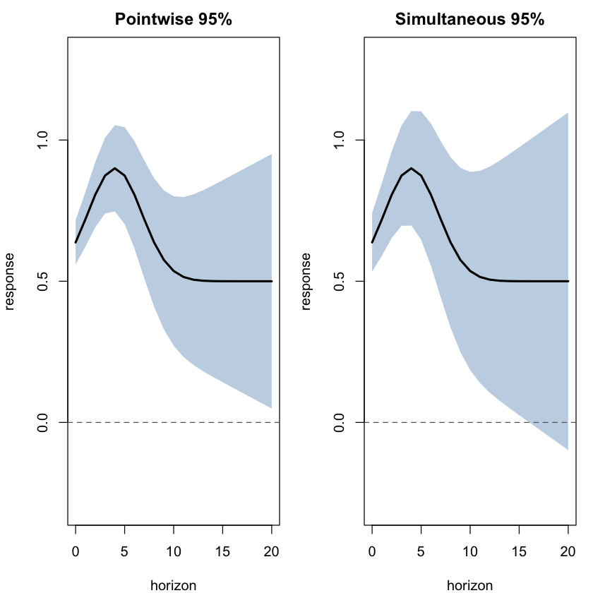

*Is the effect positive throughout $h \le 20$?* Pointwise lower stays $> 0$ — **yes**. Simultaneous lower dips below zero at long $h$ — **no**. Same data, same point estimate, different conclusions: pointwise undercover for joint claims.

## When Is a Recursive Ordering Plausible?

Bootstrap CIs presume the identification is correct. Step back to that: when does a recursive ordering actually hold?

A recursive ordering encodes a **timing assumption**: variables earlier in the order do not respond to variables later in the order **within the same period**.

**Common conventions in macro:**

- *Slow-moving* variables (output, prices) ordered first — they cannot react to financial conditions within the quarter.
- *Fast-moving* variables (interest rates, asset prices) ordered last — they react to everything within the period.
- Technology shocks often ordered first; monetary policy shocks often ordered last.

**The assumption is not in the data.** If you reorder, you get a different $B^{-1}$, different IRFs, different stories. Always report the ordering and justify it.

## Ordering Matters: A Demonstration

Take a small simulated bivariate VAR. We Cholesky-identify it under two orderings — $(v_1, v_2)$ and $(v_2, v_1)$ — and plot the impulse response of $v_2$ to a shock in $v_1$.

Same data, same model, different ordering, different answer.

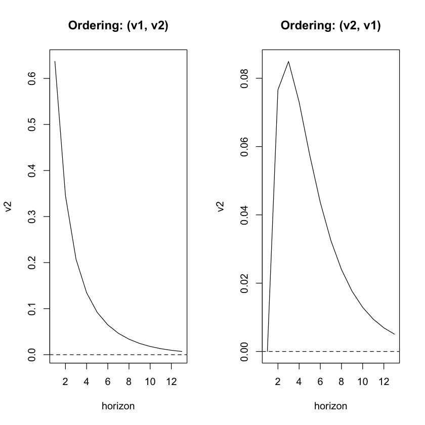

The choice of ordering is part of the **identifying assumption** — the data do not pick it.

## A Real Application: Christiano, Eichenbaum & Evans (1999)

The most influential recursive-SVAR study of monetary policy. The question:

> *How do output, prices, and the rest of the economy respond to a contractionary monetary policy shock?*

**Data.** Quarterly U.S. macro data, 1965Q1–1995Q4 (CEE’s sample).

**Variables (in the recursive ordering CEE adopt):**

- Slow block: **GDP, GDP deflator, commodity price index**
- **Federal funds rate** — the Fed’s main policy instrument over the sample
- Fast block: **total reserves, non-borrowed reserves, M2**

## Reserves and M2

**Reserves** = bank balances held at the Fed. Banks hold them to meet:

- *Reserve requirements* — a mandatory fraction of demand deposits
- *Interbank payment settlement* — payments between banks clear through Fed reserve accounts

**Two types of reserves:**

- *Non-borrowed* — from the Fed buying/selling Treasuries with banks
- *Borrowed* — from banks borrowing directly from the Fed at the *discount rate*
- Total = non-borrowed + borrowed

**The FFR** is the *interbank* overnight reserve rate (banks lending reserves to each other). The Fed targets it by adjusting **non-borrowed reserves** — the main policy lever.

**M2** = M1 (cash + checking) + savings + small CDs + retail money market funds — the *broad money supply* households and firms hold.

**Transmission.** Fed sells Treasuries → non-borrowed reserves contract → FFR rises → bank lending tightens → deposits and M2 fall. The fast-block IRFs trace this chain.

## Why CEE Include Commodity Prices: The “Price Puzzle”

In simpler VARs (without $p^{\text{com}}$), a contractionary shock *raises* prices — implausible.

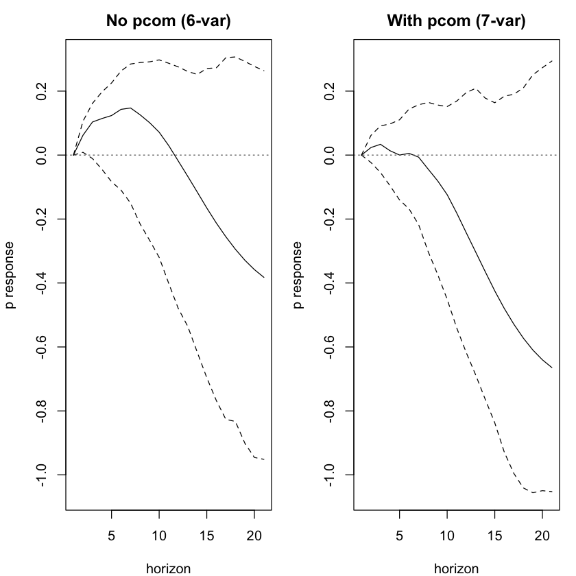

**Sims (1992).** Commodity prices are leading inflation indicators in the Fed’s information set. Omit $p^{\text{com}}$ → “policy shock” absorbs the Fed’s preemptive response → shock correlates with realized inflation → wrong sign on $p$.

## CEE: The Identifying Assumption

The ordering is a **timing story** about within-quarter behavior:

- *Slow* variables (output, prices) don’t respond to policy within the quarter — sticky prices, sluggish real activity.
- The *fed funds rate* can respond to slow variables within the quarter — the Fed sees output, prices, and commodity prices and reacts.
- *Fast* variables (reserves, money) respond to everything within the quarter — financial markets clear quickly.

The structural shock to the fed funds equation, isolated by this ordering, is the **monetary policy shock** — a quarter’s policy move that the Fed’s reaction function does not explain.

## What the Restriction Buys You

Without the ordering, the fed-funds equation residual is a **mixture**: a true policy surprise, plus the systematic Fed response to today’s slow-block news (output, prices, commodity prices).

With the ordering — and only with it — the mixture unscrambles:

$$u_{\text{ffr},t} \;=\; \underbrace{\alpha_y\,\varepsilon_{y t} + \alpha_p\,\varepsilon_{p t} + \alpha_{c}\,\varepsilon_{p^{\text{com}} t}}_{\text{policy reaction to slow-block shocks}} \;+\; \underbrace{\varepsilon_{\text{ffr},t}}_{\text{policy shock}} .$$

This is the identifying restriction **biting** — turning a residual of mixed origin into an interpretable structural object.

## CEE: Output Response

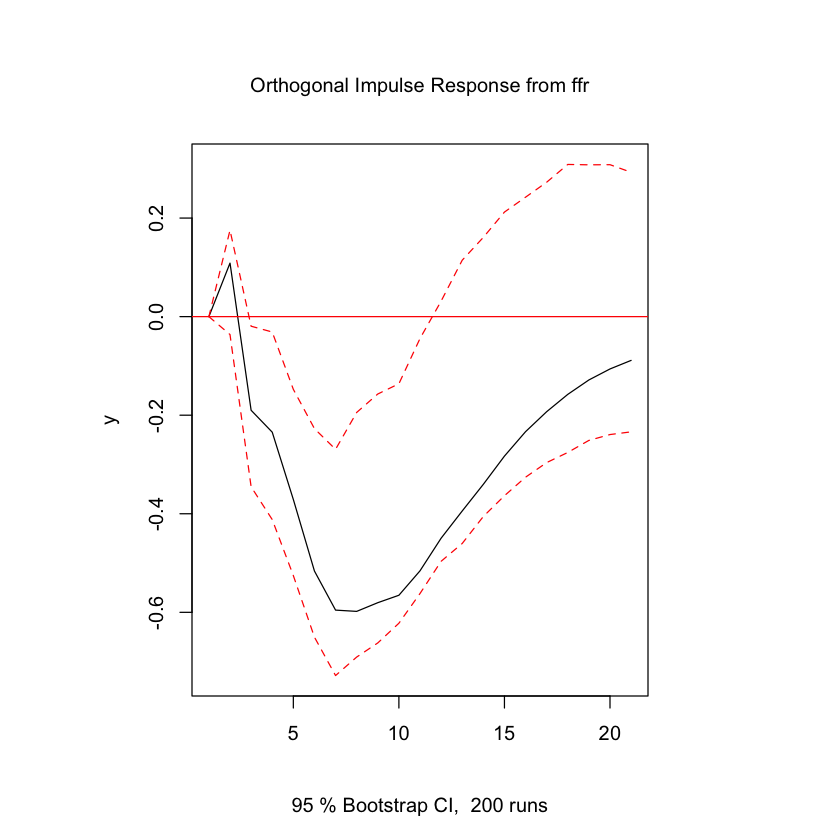

## CEE: GDP Deflator Response

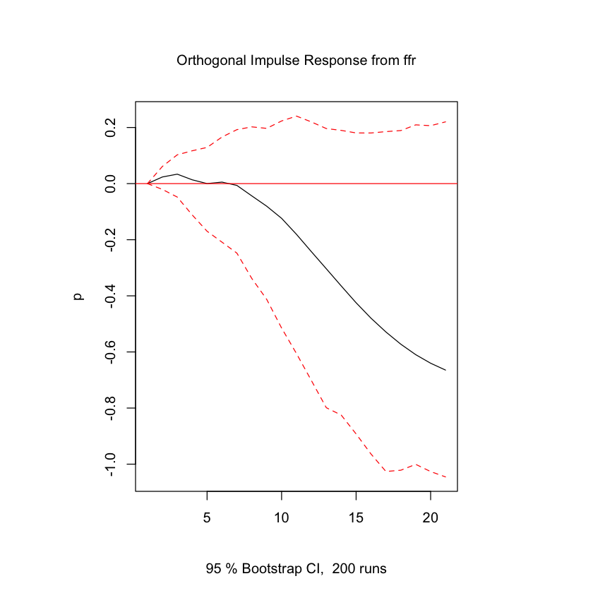

**Sluggish decline.** Bulk of the response arrives only after 1–2 years — well behind the output trough. *Output falls before prices.* Pointwise CIs straddle zero throughout — discussion next slide.

## Reading the Weak Price Response

**Calvo (sticky prices) predicts:** small short-run response, gradual decline, full long-run adjustment.

**What we see:**

- *Short run* — matches: no detectable response.
- *Long run* — ambiguous: point estimates drift down; CIs span zero.

**Why isn’t the long-run decline sharp?**

- Sample noise (short sample; bootstrap variance grows with $h$).
- Recursive identification gives a small price effect in this sample.

**Identification matters.** Different rotations → different IRFs. The data don’t pick the rotation. Identification is a modeling decision.

## CEE: Commodity Prices Response

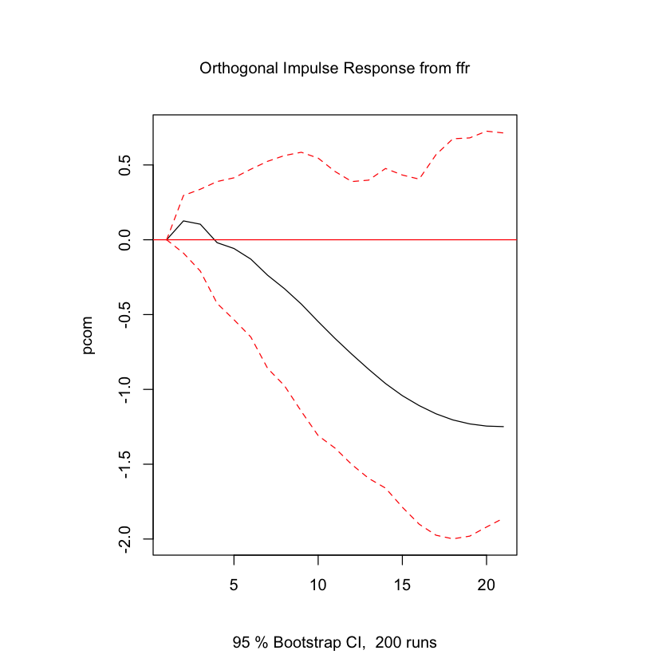

**Faster decline than $p$** — flexible-price markets clear quickly. $p^{\text{com}}$ is still in the *slow block*: the Fed *reacts* to it within-quarter (not that pcom itself is slow).

## CEE: Federal Funds Rate Response

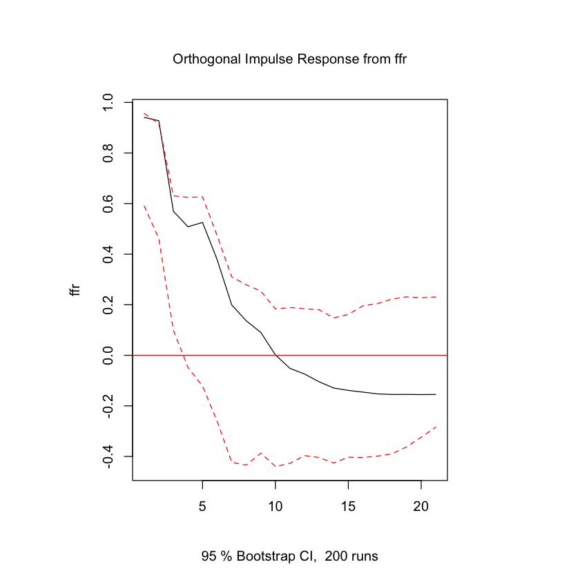

**The policy shock itself.** A one-s.d. surprise raises FFR on impact; the rate decays back over ~6–8 quarters. By construction, this response is *not* part of the systematic Fed reaction — it’s the residual orthogonal to slow-block contemporaneous shocks, the SVAR’s interpretation of *exogenous policy*.

## CEE: Non-Borrowed Reserves — the Liquidity Effect

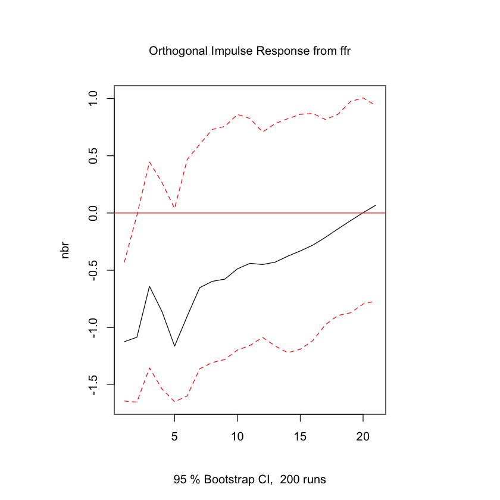

**Liquidity effect.** $\text{nbr}$ contracts sharply on impact — the Fed withdraws reserves to engineer the rate hike. (Total reserves’ response is muddier: when reserves are tight, banks under stress pay the higher discount rate to borrow from the Fed; *borrowed* reserves rise and partially offset the fall in $\text{nbr}$.)

## CEE: M2 Response

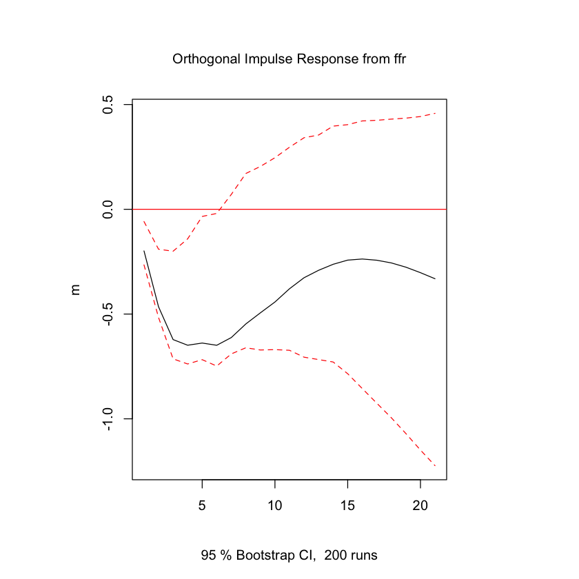

**Money supply contracts.** $M_2$ declines as the policy contraction propagates — the broad monetary aggregate moves with reserves and the rate, more gradually than $\text{nbr}$.

## Forecast Error Variance Decomposition

**What FEVD measures:**

- IRF: per-unit *effect* of one shock on variable $i$
- FEVD: that shock’s *share* of variable $i$’s variance, against all other shocks
- “What does shock $k$ do?” vs. “which shock drives $i$?”

**Decomposition.** The $h$-step forecast error is $x_{t+h} - \mathbb{E}_t x_{t+h} = \sum_{j=0}^{h-1} \Psi_j\, \varepsilon_{t+h-j}$. With $\Omega_\varepsilon = I$, variance is additive across shocks:

$$\operatorname{Var}_h(x_{i,t+h})
= \underbrace{\textstyle\sum_{j} (\Psi_j)_{i1}^2}_{\text{shock 1}}
+ \cdots
+ \underbrace{\textstyle\sum_{j} (\Psi_j)_{iK}^2}_{\text{shock $K$}}.$$

FEVD = shock $k$’s piece divided by the total:

$$\mathrm{FEVD}_{ik}(h) = \frac{\sum_{j=0}^{h-1}(\Psi_j)_{ik}^{2}}{\sum_{j=0}^{h-1}\sum_{\ell=1}^{K}(\Psi_j)_{i\ell}^{2}}.$$

Shares sum to 1; inherits meaning from the identification.

## CEE: FEVD

Share of forecast-error variance attributable to the **FFR shock**, by variable and horizon.

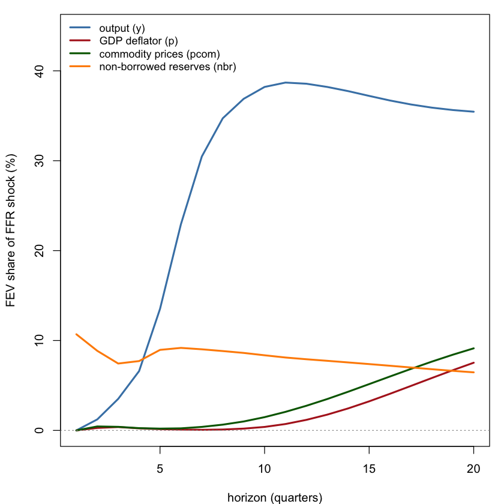

## CEE: FEVD — Takeaways

Share of forecast-error variance attributable to the **FFR shock**:

- **Output ($y$): ~35–40%** at medium–long horizons — the FFR shock is a *substantial* driver of real activity in this replication
- GDP deflator and commodity prices: $<10\%$ throughout — small share
- Non-borrowed reserves: ~10% — modest contribution

## Long-Run Identification (Blanchard–Quah)

A different idea: instead of restricting **impact** responses, restrict **long-run cumulative** responses.

The cumulative effect of a shock at horizon $\infty$ is

$$\Psi(1) = \sum_{j=0}^{\infty} \Psi_j = \Phi(1)\, B^{-1}.$$

For a stable VAR(1), iterating gives $\Phi_j = A_1^j$, so

$$\Phi(1) = \sum_{j=0}^{\infty} A_1^j = (I - A_1)^{-1}.$$

(For VAR$(p)$: $\Phi(1) = (I - A_1 - \cdots - A_p)^{-1}$.)

**A long-run zero restriction** like

$$\Psi(1)_{ij} = 0$$

says shock $j$ has no permanent effect on the level of variable $i$.

## BQ: Bivariate Worked Example

For $K=2$ with one long-run zero, $\Psi(1) = CB^{-1}$ is lower triangular — an *ordering* assumption, the long-run analog of recursive ordering, imposed on $\Psi(1)$ rather than $B^{-1}$.

Square $\Psi(1)$:

$$\Psi(1)\Psi(1)' \;=\; C\,\Sigma_u\,C' \;\equiv\; V,$$

where $C = (I - A_1 - \cdots - A_p)^{-1}$. $V$ is data. Take Cholesky: $LL' = V \Rightarrow \Psi(1) = L$, then $B^{-1} = C^{-1} L$.

With $V = \begin{bmatrix} v_{11} & v_{12}\\ v_{12} & v_{22} \end{bmatrix}$,

$$L = \begin{bmatrix}
\sqrt{v_{11}} & 0 \\
v_{12}/\sqrt{v_{11}} & \sqrt{v_{22} - v_{12}^2/v_{11}}
\end{bmatrix}.$$

Same Cholesky bivariate formulas as the recursive case — applied to the long-run covariance $V$ rather than $\Sigma_u$.

## A Real Application: Blanchard & Quah (1989)

The founding long-run-restriction SVAR. The question:

> *What are the dynamic effects of aggregate demand and supply disturbances? How much of the variation in output and unemployment does each account for?*

**Data.** U.S. quarterly, 1948Q1–1987Q4 (BQ’s sample).

**Variables.** Output growth $\Delta y_t$ and unemployment $U_t$. Bivariate VAR(8).

## Supply and Demand Disturbances

Two basic kinds of disturbance hit the economy:

- **Supply disturbances** — oil shocks, technology, capital accumulation, labor-force changes, weather, regulation. They change *what the economy can produce* — its productive capacity.
- **Demand disturbances** — monetary policy, fiscal policy, household and business spending, financial conditions, “animal spirits.” They change *how much is spent* at given capacity.

**The distinction matters for policy.**

- *Demand shortfall* — capacity is intact, only spending has fallen. Monetary and fiscal stimulus are designed for this case.
- *Supply contraction* — capacity itself has shrunk. Stimulating into a smaller economy just raises prices.

## Long-Run Neutrality

**Output ($Y_t$).** Long-run output is determined by supply-side fundamentals — capital, labor, productivity. Quantity theory:

$$MV = PY, \qquad Y \to Y^* \;\Longrightarrow\; \Delta M \to \Delta P.$$

- *Demand* (movements in $M$): nominal effect only — $\Delta P$, not $\Delta Y$. **Long-run neutral on output.**
- *Supply*: shifts $Y^*_t$ itself (productivity, capital, labor force). **Permanent on output.**

**Unemployment ($U_t$).** Long-run unemployment is the natural rate $U^*$, set by labor-market frictions, demographics, and institutions. Neither supply nor demand shocks change $U^*$. **Both shocks long-run neutral on unemployment.**

**The asymmetry BQ exploits:** only supply moves output’s long-run level; nothing moves unemployment’s.

## BQ: The Identifying Restriction

The asymmetry — *demand transient, supply permanent* — gives a single zero in the long-run cumulative response matrix $\Psi(1)$:

$$\Psi(1)_{\Delta y,\, d} = 0$$

- The cumulative response of $\Delta y$ to a demand shock is zero. Since the level $y$ is the running sum of $\Delta y$, this means **demand has no permanent effect on the level of output**.
- Row $\Delta y$ = output growth (first variable in $x_t$); column $d$ = demand shock.
- One restriction — exactly the $K(K-1)/2 = 1$ count for the bivariate case.

## BQ: Supply Shock

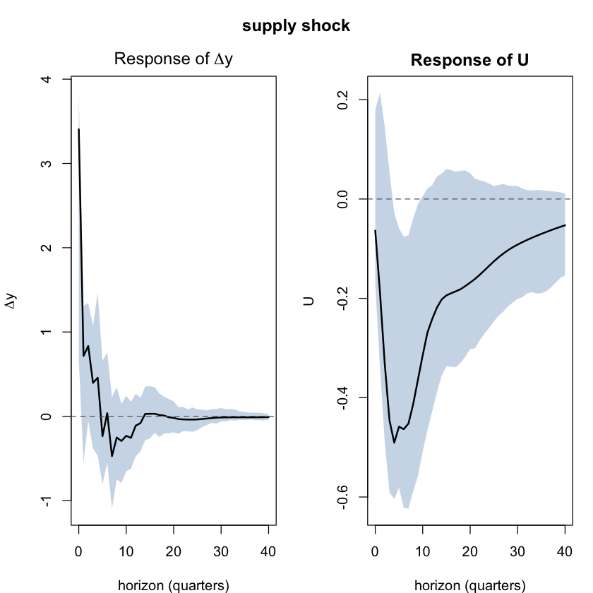

**Permanent on output, persistent on unemployment.**

## BQ: Demand Shock

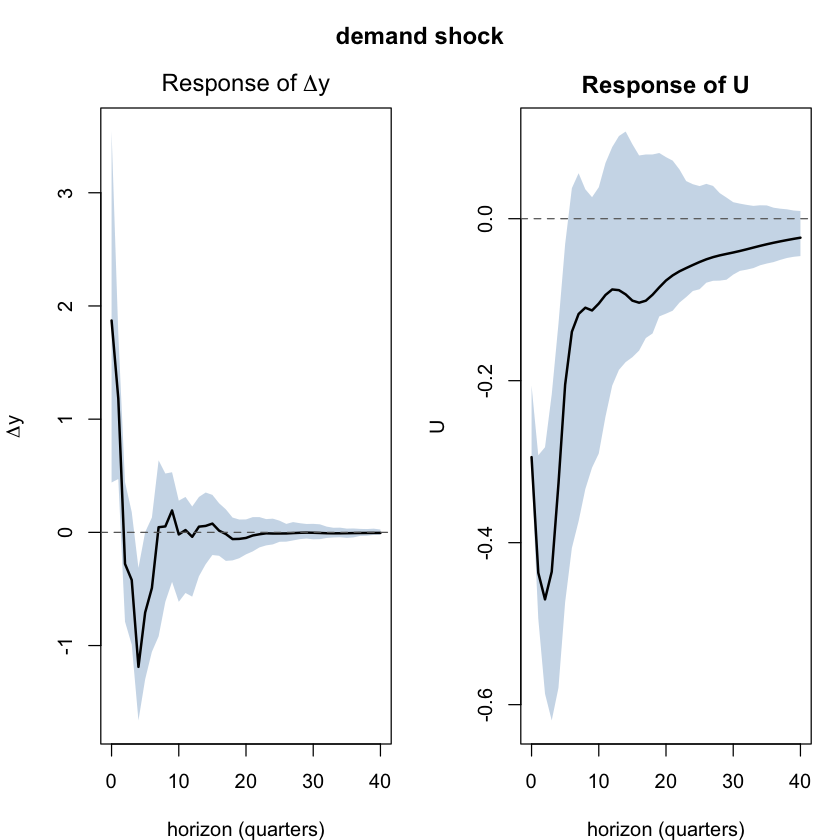

**Transient on output, hump on unemployment.**

- **$\Delta y$ panel**: rises on impact, then declines back to zero (possibly overshooting briefly negative). *Cumulating* this IRF gives zero — the imposed long-run neutrality.
- **$U$ panel**: unemployment falls in a hump, troughing around horizon 2–3; gradual recovery.

## Long-Run vs. Short-Run: A Comparison

|  | Cholesky | Blanchard–Quah |
| --- | --- | --- |
| Restriction on: | impact ($B^{-1}$) | long-run sum ($\Psi(1)$) |
| Form: | zeros in $B^{-1}$ | zeros in $\Psi(1)$ |
| Information needed: | within-period timing | long-run neutrality |
| Computation: | $\mathrm{chol}(\Sigma_u)$ | $\mathrm{chol}(C\Sigma_u C')$ |

The two schemes encode different economic information. Use whichever is more defensible for the question at hand.

## Sign Restrictions

Both Cholesky and Blanchard–Quah are **point-identifying**: the restrictions pin down a single $B^{-1}$.

Sign restrictions are weaker — they say only:

> *A monetary contraction raises the policy rate, lowers output, and lowers inflation, on impact (or for the first $h$ horizons).*

That is **set identification**: we keep every $B^{-1}$ consistent with the data ($B^{-1}B^{-1\prime} = \Sigma_u$) and with the sign pattern. The IRF becomes a **set** of curves, not a single curve.

## Identification as a Choice of $Q$

Structural identification requires $\Sigma_u = B^{-1}(B^{-1})'$ (with $\Omega_\varepsilon = I$).

The Cholesky factor $L$ is one solution. But for **any** orthogonal $Q$ ($QQ' = I$):

$$(LQ)(LQ)' = L\, QQ'\, L' = LL' = \Sigma_u.$$

So $\tilde B^{-1} = LQ$ is *also* a valid decomposition. **$Q$ parametrizes everything the data leave unidentified.**

Each identification scheme is a rule for picking $Q$:

- **Cholesky**: $Q = I$ → $B^{-1} = L$ (lower triangular).
- **BQ**: pick the unique $Q$ that makes $\Psi(1) = C \cdot LQ$ lower triangular.
- **Sign restrictions**: keep the **set** of $Q$’s for which $\tilde\Psi_h = \Phi_h \cdot LQ$ satisfies the sign pattern.

## Sign Restrictions: The Algorithm

We search the identified set by Monte Carlo over $Q \in O(K) = \{Q : QQ' = I\}$:

1. **Sample** $Q$ uniformly from $O(K)$ — standard algorithm (Stewart 1980).
2. **Form candidate** $\tilde B^{-1} = LQ$ where $L = \mathrm{chol}(\Sigma_u)$.
3. **Check signs.** For each column $k$, compute $\tilde\Psi_h^{(k)} = \Phi_h \cdot (\tilde B^{-1})_{\bullet,\, k}$ at horizons $0, \ldots, h_0$. If the sign pattern holds, keep that column’s full IRF.
4. **Repeat many times.** The accepted IRFs form the **identified set**.

## External Instruments (Proxy SVAR)

Suppose we have a variable $z_t$ — outside the VAR — that is correlated with **one** structural shock and **only** that shock:

$$\mathbb{E}[z_t\, \varepsilon_{1t}] \neq 0,
\qquad
\mathbb{E}[z_t\, \varepsilon_{jt}] = 0\ \ (j \neq 1).$$

This is an **instrument** for $\varepsilon_{1t}$. It directly identifies the **first column of $B^{-1}$**, without imposing any timing or long-run restrictions.

## Proxy SVAR: Identifying $b$ — Direction

Goal: recover $b = (B^{-1})_{\bullet 1}$ — the impact response to shock $\varepsilon_{1t}$.

**Cross-moment isolates the column.** From $u_t = B^{-1}\varepsilon_t$ and the instrument’s properties ($\mathbb{E}[z_t\varepsilon_{1t}] = \alpha$, others $= 0$):
$$\mathbb{E}[u_t z_t] \;=\; B^{-1}\,\mathbb{E}[\varepsilon_t z_t] \;=\; b\cdot\alpha.$$

The cross-moment is $b$ scaled by the unknown $\alpha$.

**OLS estimates this.** Regress $\hat u_t$ on $z_t$ (no intercept):
$$\hat\beta \;=\; \frac{\sum_t \hat u_t z_t}{\sum_t z_t^2} \;\xrightarrow{p}\; b\cdot c, \qquad c = \frac{\alpha}{\mathbb{E}[z_t^2]}.$$

OLS recovers $b$ **up to the unknown scalar $c$** — direction yes, magnitude no.

## Proxy SVAR: Identifying $b$ — Magnitude

**Variance constraint pins $|c|$.** $\Omega_\varepsilon = I \Rightarrow \Sigma_u = B^{-1}(B^{-1})'$, hence $b'\,\Sigma_u^{-1}\,b = 1$. Plug in $\hat\beta = c\cdot b$:
$$\hat\beta'\,\Sigma_u^{-1}\,\hat\beta \;=\; c^2 \;\;\Rightarrow\;\; |c| = \sqrt{\hat\beta'\,\widehat\Sigma_u^{-1}\,\hat\beta}.$$

**Result.** $\hat b = \hat\beta / |c|$, with sign chosen by the **positive-diagonal convention** from earlier.

*Other columns of $B^{-1}$ remain unidentified* — fine if we only need the IRF for shock 1.

## Proxy SVAR: Application — The Credit Channel

We use Proxy SVAR to identify a **financial transmission channel** for monetary policy that recursive VARs without a credit variable can’t show.

**Setup.**

- 4-variable VAR: output $y$, GDP deflator $p$, FFR, BAA–10y credit spread
- Sample: 1994Q1–2007Q4 (HF series begins 1994; pre-ZLB to keep FFR informative)
- 4 lags

**Instrument.** Quarterly-summed **FF4 surprises** from the [USMPD database](https://www.frbsf.org/research-and-insights/data-and-indicators/us-monetary-policy-event-study-database/) (Bauer-Swanson) — change in 4-month-ahead fed-funds futures in a 30-min window around FOMC events.

*Spirit follows Gertler-Karadi (2015); we use the updated USMPD series in place of the original Gürkaynak-Sack-Swanson data.*

## Federal Funds Futures — Mechanics

**FF4** is the federal funds futures contract for the 4-month-ahead month, traded on the CME.

**Quote convention.** The contract cash-settles at expiration to $100 - r_{\text{realized}}$ (where $r$ is the average realized FF rate over the contract month). By no-arbitrage:
$$P_t \;\approx\; 100 - \mathbb{E}_t[r_{4\text{-month ahead}}],$$
so the **implied rate** $= 100 - P_t$ recovers market expectations from the price.

**Trading mechanics — not a spot purchase.**

- No upfront principal. You post a refundable **margin** (security deposit, ~$1,000–$2,000 per contract).
- Daily P&L = (price change) × **contract multiplier** (~$41.67 per basis point for the 30-day FF contract — fixed by CME contract spec, not by market).
- At expiration, the contract cash-settles; margin is returned net of cumulative P&L.

## Why FF4 Surprises Identify the Monetary Shock

**The “surprise”** = change in the FF4 **implied rate** over a 30-minute window around an FOMC announcement (in basis points; positive = rate revised up).

**The 30-min window argument.**

- In that window, nothing else macro-relevant happens — no GDP releases, no inflation prints, no fiscal news.
- The only “news” is the FOMC announcement itself.
- Change in implied rate = the part markets *didn’t* already expect = the **unexpected component of policy** = the monetary shock $\varepsilon_{m,t}$.

So $z_t$ is **relevant** (it IS the surprise component) and **exogenous** (other shocks don’t move in 30 min).

**Quarterly aggregation.** Fed meets ~2× per quarter → 2 event-time surprises per quarter. Sum within-quarter to get the quarterly instrument $z_t$. Aggregation preserves both validity properties.

## Proxy SVAR: Credit Spread Response

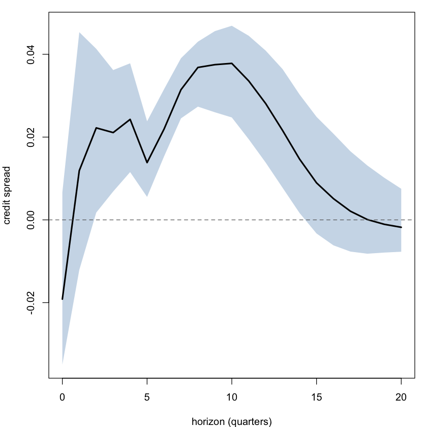

**The credit channel.**

- Persistent widening of the BAA–Treasury spread, peaking ~8–10 quarters out.
- Impact response negative (~−0.02), but CI spans zero — not significant.
- Gertler–Karadi (2015) headline: monetary policy transmits via **financial frictions** — a channel a recursive VAR without a credit variable can’t show.

## Proxy SVAR: Standard IV Concerns

Proxy SVAR uses an external $z_t$ to identify one shock — but the identification rests on standard IV conditions.

**Exogeneity is plausible, not testable**

- $\mathbb{E}[z_t\,\varepsilon_{jt}] = 0$ for $j \neq 1$ cannot be checked directly — a general IV concern.
- Concrete worry for FF4: the *Fed information effect* — surprises may release the Fed’s private information about the economy, not pure policy stance (Nakamura–Steinsson, 2018).
- If so, $z_t$ is correlated with non-policy shocks; identification breaks.

**Weak-instrument risk** (relevance)

- Relevance only requires $\mathbb{E}[z_t\,\varepsilon_{1t}] \neq 0$ — the correlation can be arbitrarily small.
- In practice, $z_t$ may explain little of $u_t$; first-stage $F < 10$ is common, and the identified $b$ has large standard errors.

## Proxy SVAR: What Shock Do We Identify?

Even when exogeneity and relevance hold, the instrument identifies the response to a *specific type* of shock — not a generic one.

**LATE-style heterogeneity**

- The identified IRF reflects only the component of $\varepsilon_{1t}$ that is correlated with $z_t$.
- FF4 surprises capture FOMC-window news; slow-moving policy shifts (gradual forward guidance, off-meeting balance-sheet operations) produce no FF4 surprise and so don’t enter the identified IRF.
- The IRF is *local* to the variation $z_t$ captures — analogous to LATE in cross-sectional IV.

## Summary of Identification Schemes

| Scheme | Restriction | What it pins down | Cost |
| --- | --- | --- | --- |
| Cholesky | Triangular $B^{-1}$ | All shocks, given order | Strong timing |
| Long-run (BQ) | Zeros in $\Psi(1)$ | All shocks | Long-run neutrality |
| Sign restrictions | Sign of impact / IRFs | Set of admissible IRFs | Set, not point ID |
| Proxy SVAR (IV) | Instrument exogeneity | One column of $B^{-1}$ | Need a credible $z_t$ |

None of these is “the right” scheme. Each makes economic content explicit. Choosing among them is a **modeling decision**, not a statistical one.

## Standard SVAR and the $C(L)$ Structure

The general relationship between reduced-form innovations and structural shocks:
$$u_t \;=\; C(L)\,\varepsilon_t.$$

Standard SVAR is the *special case* $C(L) = B$ (constant matrix). Identify $B$ from $\Sigma_u$ $+$ restrictions, recover $\varepsilon_t = B^{-1} u_t$.

**If $C(L)$ has lags but is invertible:** the VAR’s $\Phi(L)$ (with enough lags) absorbs the lag structure, leaving $u_t = B\,\varepsilon_t$ in the limit. Standard SVAR still works.

**If $C(L)$ is non-invertible:** no VAR — finite or infinite order — can recover $\varepsilon_t$ from past $u$’s. This is **non-fundamentality**.

The canonical source of non-invertible $C(L)$: **anticipation**.

## $C(L)$ and the Structural MA $M(L)$

From $\Phi(L)\,y_t = C(L)\,\varepsilon_t$, the structural MA of observables is
$$y_t = M(L)\,\varepsilon_t, \qquad C(L) = \Phi(L)\,M(L).$$

- Determinant rule: $\det C(z) = \det\Phi(z) \cdot \det M(z)$.
- Stationarity: $\det\Phi(z)$ has no inside-disk roots.
- $\Rightarrow$ inside-disk roots of $\det C(z)$ are exactly those of $\det M(z)$.

$\Rightarrow$ checking $C(L)$ non-invertibility reduces to checking $\det M(z)$ for inside-disk roots. The next slide does this in a GE model.

## LWY (2013): Setup

Neoclassical growth model with $q$-period tax foresight.

**Model ingredients**

- Preferences: log utility, discount factor $\beta \in (0,1)$.
- Production: $A_t K_{t-1}^\alpha$ (capital share $\alpha \in (0,1)$, full depreciation, inelastic labor).
- Government: distortionary tax at rate $\tau_t$ (steady-state level $\tau$), rebated lump-sum.

**Observables**

- $a_t$ — log TFP.
- $\hat K_t$ — log capital deviation from steady state.

**Structural shocks**

- $\varepsilon^A_t$ — TFP innovation.
- $\varepsilon^\tau_t$ — tax news at $t$, announces $\hat\tau_{t+q}$.

## LWY (2013): Equilibrium $M(L)$

Solving the equilibrium (log utility, full depreciation, Cobb–Douglas production) gives, for $q = 2$:
$$M(L) \;=\;
\begin{pmatrix}
1 & 0 \\
\dfrac{1}{1 - \alpha L}
& -\dfrac{\kappa(L + \theta)}{1 - \alpha L}
\end{pmatrix},$$
with $\theta = \alpha\beta(1-\tau) \in (0,1)$ and $\kappa = (1-\theta)\tau/(1-\tau)$.

- Row 1 (TFP): exogenous to taxes, responds 1-to-1 to its own shock.
- Row 2 (capital):
  - TFP: AR dynamics $(1-\alpha L)^{-1}$.
  - tax news: numerator $-\kappa(L+\theta)$ (impact $-\kappa\theta$, $L^1$ coefficient $-\kappa$), AR filter $(1-\alpha L)^{-1}$.

## LWY (2013): Non-Invertibility

Determinant:
$$\det M(z) \;=\; -\frac{\kappa(z+\theta)}{1-\alpha z},
\qquad \text{root at } z = -\theta.$$

Since $\theta = \alpha\beta(1-\tau) \in (0,1)$, the root sits inside the unit disk. $M(L)$ non-invertible $\Rightarrow C(L)$ non-invertible $\Rightarrow$ standard SVAR fails.

**Economic intuition.**

- Coefficient on current news in today’s capital is $-\kappa\theta$ (from row 2 of $M_0$).
- Larger $\theta$ $\Rightarrow$ larger response of capital to current news $\Rightarrow$ news more visible in today’s data $\Rightarrow$ closer to invertibility.
- Smaller $\theta$ $\Rightarrow$ news barely affects today’s capital $\Rightarrow$ news invisible until tax change at $t+q$ $\Rightarrow$ severe non-invertibility.
- Standard parameters ($\alpha \approx 0.3$, $\beta \approx 0.99$, $\tau \approx 0.25$): $\theta \approx 0.22$, well inside disk.

## Proxy SVAR: Impact Response

Suppose we have an external instrument $z_t$ with

- *Relevance*: $\mathrm{Cov}(z_t,\,\varepsilon^\tau_t) \neq 0$.
- *Exogeneity to other current shocks*: $\mathrm{Cov}(z_t,\,\varepsilon^A_t) = 0$.
- *Exogeneity to past shocks*: $\mathrm{Cov}(z_t,\,\varepsilon_{s}) = 0$ for all $s < t$.

**Impact response.** Under non-invertibility, $u_t = C(L)\,\varepsilon_t = \sum_{j \geq 0} C_j\,\varepsilon_{t-j}$. Then
$$\begin{align*}
\mathrm{Cov}(u_t,\, z_t)
&= \sum_{j \geq 0} C_j\,\mathrm{Cov}(\varepsilon_{t-j},\, z_t) \\
&= C_0\,\mathrm{Cov}(\varepsilon_t,\, z_t)
\quad\text{(past-shock terms zero)} \\
&= (C_0)_{\bullet,\tau} \cdot \mathrm{Cov}(z_t,\,\varepsilon^\tau_t).
\end{align*}$$
Since $C_0 = \Phi(0)\,M_0 = M_0$, this recovers $(M_0)_{\bullet,\tau}$ — the impact column ($h = 0$ of the IRF).

**Full IRF.** For later horizons, use local-projection IV (LP-IV).

## Practical Guidance

- **Identification is the key assumption** — the data do not choose it for you.
- **Always report the ordering / restrictions used**, with a one-line economic justification.
- **Check robustness across schemes.** If a result holds under Cholesky with two orderings, plus sign restrictions, plus a Proxy SVAR — that is meaningful. If it flips, that is also meaningful.
- **Inspect the IRFs critically.** Implausible signs or magnitudes are a warning that the identification doesn’t fit the data.
- **Confidence bands matter.** A “significant” IRF whose 95% band crosses zero everywhere except at horizon 3 is not a robust finding.

## What SVARs Do — and Don’t

**Do** (given an identification):

- IRFs — effects of structural shocks on each variable
- FEVDs — share of each variable’s variance attributable to each shock
- Historical decomposition — which shocks drove observed paths
- Counterfactuals — paths under hypothetical shock sequences

**Don’t:**

- Adjudicate which identification is right — data don’t choose
- Tell you which shocks matter economically — theory does
- Handle structural breaks or regime instability
- Capture non-linear effects (asymmetric responses, threshold dynamics)

## Beyond This Unit

Standard extensions worth knowing the names of:

**Estimation:**

- **Local projections (Jordà, 2005)** — IRFs by direct $h$-step regressions; no MA inversion
- **FAVAR (Bernanke, Boivin, Eliasz, 2005)** — augment the VAR with factors from a large panel
- **Bayesian VARs** — shrinkage priors for high-dimensional systems

**Identification:**

- **Heteroskedasticity (Rigobon, 2003; Lewis, 2021)** — exploit changes in variance regimes to identify $B^{-1}$
- **Non-Gaussian identification (Lanne, Meitz, Saikkonen, 2017)** — independent non-Gaussian components uniquely identified up to scale and permutation